# 緑本 1-3章

# ポアソン分布

## ポアソン分布の性質

性質

- $y\in \left\{ 0,1,2,\ldots \ldots ,\infty \right\}$の値を取り、全ての$y$について和を取ると1になる。
- 確率分布の平均は$\lambda$である
- 分散と平均が等しい（$\lambda$)

ポアソン分布が選ばれる時、以下のような場合があげられる。

1. データに含まれる値$y_{i}$が$\left\{ 0,1,2,\ldots ,\right\}$といった非負の整数である（カウントデータ）
2. $y_{i}$に下限はあるが、上限はわからない
3. 平均と分散が大体等しい

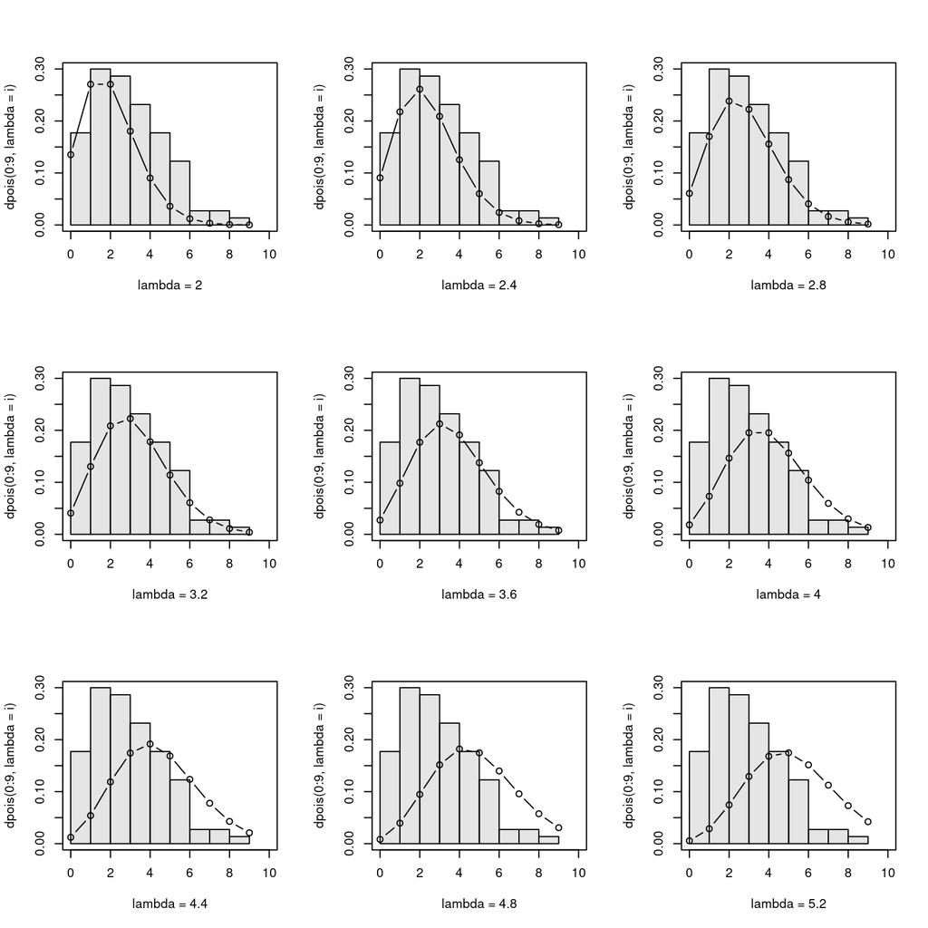

```r
data <- rpois(n = 100, lambda = 3.56)

# dpois関数は、平均lambdaのポアソン分布の場合、第一引数となる確率を返す関数
par(mfrow=c(3,3))
for (i in seq(2,5.2,0.4)){
    hist(data, labels = F, xlim=c(0,10), ann = F, xaxt="n", yaxt="n", col=rgb(0, 0, 0, alpha=0.1))
    par(new=T)
    plot(0:9, dpois(0:9, lambda = i), type = "b", xlab = paste0("lambda = ", i), xlim=c(0,10), ylim=c(0,0.3))
}
```

## ポアソン分布の最尤推定

最尤推定は、どんな統計モデルにも適用できる。  
「当てはまりの良さ」を表す統計量を最大にするようなパラメータの値を探そうとするパラメータ推定方法。

尤度の実態は、**ある値$\lambda$を定めた時にすべての個体$i$についての$p(y_{i}|\lambda)$の積**のこと。  
積になる理由は、それぞれの事象が同時に真である確率を計算したいから。イメージとして、その積が大きいほど当てはまりが良いとわかる。

$$\begin{align}
&\begin{split}
L\left( \lambda \right) &=p\left( y_{1}| \lambda \right) \times p\left( y_{2}| \lambda \right) \times \ldots \times p\left( y_{i}| \lambda \right) \\ \\
&=\prod _{i}p\left( y_{i}| \lambda \right) \\
&=\prod _{i}\dfrac{\lambda ^{y_{i}}\exp \left( -\lambda \right) }{y!}\\
\end{split}
\end{align}$$

この尤度関数はそのままだと扱いづらいので、対数変換した対数尤度関数を使うことが多い。

$$\log L\left( \lambda \right) =\sum _{i}\left( y_{i}\log \lambda -\lambda -\sum ^{y_{i}}_{k}\log k\right)$$

対数尤度は尤度の単調増加関数なので、対数尤度が最大になる$\lambda$において尤度も最大になる。

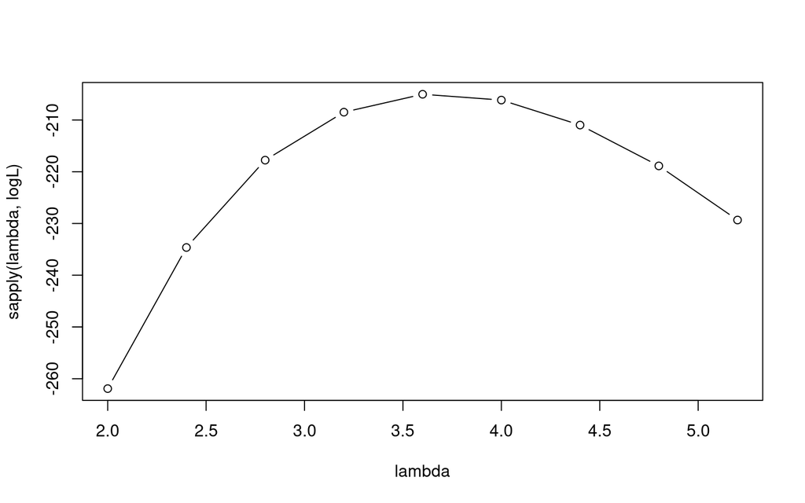

```r
data <- rpois(n = 100, lambda = 3.56)

logL <- function(m){
    sum(dpois(data, m, log = T))
}

lambda <- seq(2,5.2,0.4)
plot(lambda, sapply(lambda, logL), type = "b")
```

最尤推定を一般化すると、$\theta$をパラメタとする確率分布から観測データ$y_{i}$が発生した場合、その確率を$p(y|\theta)$とすると、尤度は、

$$L\left( \theta | Y\right) =\prod _{i}p\left( y_{i}| \theta \right)$$

対数尤度は

$$\log L\left( \theta | Y\right) =\sum _{i}\log p\left( y_{i}| \theta \right)$$

尤度推定はこの対数尤度を最大にするような$\widehat{\theta }$を探し出すこと。

# 最尤推定値のばらつき

乱数で発生させた標本の平均は生成するごとに異なる。  
試行ごとに最尤推定値(標本平均)$\hat\lambda$が異なるということ。  
試しにポアソン分布を使った乱数実験を行うと、

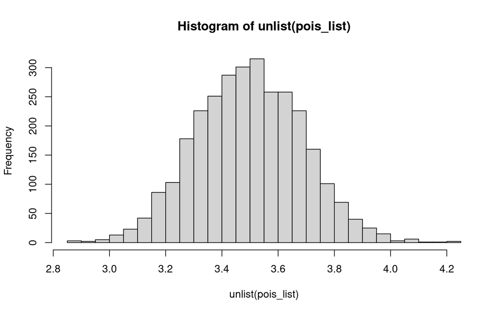

```r
pois_list <- list()

for (i in 1:3000){
    pois_list[i] <- mean(rpois(100, 3.5))
}

hist(unlist(pois_list), breaks = 20)
```

このような推定値のばらつきを標準誤差という。大きさは調査個体数に依存する。  
標本が大きければ誤差が小さくなるのはイメージしやすい。 通常、分析を行う際は、真の分布が分からない状態で分析を行う。推定値のばらつきを見る時は、得られた観測データから推定された標本平均$\hat\lambda$から乱数を発生させて見積もることになる。

# 統計モデルの要点：乱数発生・推定・予測

**数字の羅列を見た時に「このデータはどのような確率分布から発生したと考えられるか」と考えることがモデリングの第一歩になる。**  
仮に、ポアソン分布を例にとった場合、「パラメータ$\lambda$はどんな値？」の問いに答える事が「**推定（または当てはめ）**」

統計モデルで重要なのは、もう一つ予測。推定で得られた統計モデルを使って**次のデータ**の分布を見積もることが**予測**。

# 確率分布の選び方

データを見た時に考える事。

- 説明したいデータは、離散値か、連続値か？
- データの範囲は？
- 標本の分散と平均の関係は？

もしカウントデータだったら、まずは以下の2候補から。

- **ポアソン分布** データが離散値、0以上の範囲、上限なし、平均 $\fallingdotseq$ 分散
- **二項分布** データが離散値、0以上で有限の範囲、分散が平均の関数

連続であれば以下から。

- **正規分布** データが連続値、範囲が$\left[ -\infty ,+ \infty \right]$、分散と平均が無関係に決まる
- **ガンマ分布（Γ分布）** データが連続値、範囲が$\left[ -\infty ,+ \infty \right]$、分散は平均の関数

複雑な分布の場合は、確率分布を混合させることもある。

# 一般化線形モデル（GLM）

```r
library(tidyverse)

data <- read.csv("../kubobook_2012/poisson/data3a.csv")
```

data3はこれから扱う種子数データのサンプルデータ。  
xが体サイズ、yが種子数、fが施肥処理の因子。

```r
data %>% head()
```

```
## # A tibble: 6 x 3
##       y     x f
##   <int> <dbl> <chr>
## 1     6  8.31 C
## 2     6  9.44 C
## 3     6  9.5  C
## 4    12  9.07 C
## 5    10 10.2  C
## 6     4  8.32 C
```

```r
data  %>% summary()
```

```
##        y               x               f
##  Min.   : 2.00   Min.   : 7.190   Length:100
##  1st Qu.: 6.00   1st Qu.: 9.428   Class :character
##  Median : 8.00   Median :10.155   Mode  :character
##  Mean   : 7.83   Mean   :10.089
##  3rd Qu.:10.00   3rd Qu.:10.685
##  Max.   :15.00   Max.   :12.400
```

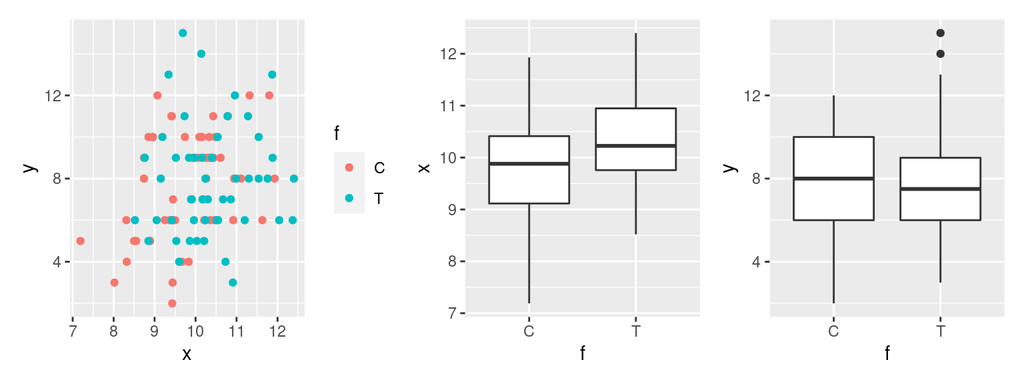

```r
library(patchwork)

g1 <- ggplot(data) +
  geom_point(aes(x = x, y = y, col = f))

g2 <- ggplot(data) +
  geom_boxplot(aes(x = f, y = x))

g3 <- ggplot(data) +
  geom_boxplot(aes(x = f, y = y))

g1 + g2 + g3
```

ここでは、ある個体iについて種子数が$y_{i}$である確率$p(y_{i}|\lambda_{i})$はポアソン分布に従っていて、

$$p\left( y_{i}| \lambda _{i}\right) =\dfrac{\lambda_{i}^{y_{i}}\exp \left( -\lambda _{i}\right) }{y_{i}}$$

と仮定する。

## 線形予測子と対数リンク関数

$$\lambda _{i}=\exp \left( \beta _{1}+\beta_{2}x_{i}\right)$$

であるとした場合、$\beta _{1}$が切片、$\beta _{2}$が傾きと呼ばれる。  
このモデルの式は以下に変形できる。

$$\log \lambda _{i}=\beta_{1} +\beta_{2} x_{i}$$

この右辺を線形予測子、右辺をリンク関数という（この場合の右辺は**対数リンク関数**と呼ばれる）。ポアソン回帰におけるGLMでは対数リンク関数が良く使われる。理由は、「推定計算に都合が良く」かつ「わかりやすい」から。  
推定計算に都合が良いのは、線形予測子>=0の為。（ポアソン分布の平均は非負でなくてはならない条件に都合が良い。）  
また、わかりやすいのは、要因の効果が積で表されるから。

## 当てはめと当てはまりの良さ

ポアソン回帰とは、ポアソン分布を使った統計モデルの当てはめで、このモデルの対数尤度$logL$が最大になるパラメータ$\hat\beta_{1}$と$\hat\beta_{2}$の推定値を決める事に等しい。このモデルの対数尤度は

$$\log L\left( \beta_{1},\beta _{2}\right) =\sum _{i}\log \dfrac{\lambda _{i}^{y_{i}}\exp \left( -\lambda _{i}\right) }{y_{i}!}$$

$$\log \lambda _{i}=\beta_{1} +\beta_{2} x_{i}$$

Rでの推定は以下のように行う。

```r
fit <- glm(y ~ x, data = data, family = poisson) # poissonでポアソン分布を指定
summary(fit) # 詳細表示
```

```
##
## Call:
## glm(formula = y ~ x, family = poisson, data = data)
##
## Deviance Residuals:
##     Min       1Q   Median       3Q      Max
## -2.3679  -0.7348  -0.1775   0.6987   2.3760
##
## Coefficients:
##             Estimate Std. Error z value Pr(>|z|)
## (Intercept)  1.29172    0.36369   3.552 0.000383 ***
## x            0.07566    0.03560   2.125 0.033580 *
## ---
## Signif. codes:  0 '***' 0.001 '**' 0.01 '*' 0.05 '.' 0.1 ' ' 1
##
## (Dispersion parameter for poisson family taken to be 1)
##
##     Null deviance: 89.507  on 99  degrees of freedom
## Residual deviance: 84.993  on 98  degrees of freedom
## AIC: 474.77
##
## Number of Fisher Scoring iterations: 4
```

以上から、$\hat\beta_{1} = 1.29$、$\hat\beta_{2} = 0.0757$とわかる。

$std.error$はそれぞれの推定値のばらつきを標準偏差で表したもの。「同じ調査方法で同数の別データを取り直してみても、最尤推定値は結構変わるため、そのばらつきを表している」と理解する。

$z~~value$は最尤推定値をSE（std error)で割った値。推定値が0から十分に離れているかどうかの目安（？）

$Pr(>|z|)$は、このglmに限定すれば、平均がz値の絶対値であり、標準偏差が1の正規分布における$-\infty$から0までの値を取る確率の2倍（？）  
推定値が0に近い事を表現する方法の一つ。

Rでこのモデルの最大対数尤度を評価するには、

```r
logLik(fit)
```

```
## 'log Lik.' -235.3863 (df=2)
```

対数尤度は-235.4くらいで、自由度が2(パラメータが2個$\hat\beta_{1},\hat\beta_{2}$）であることを表している。

## ポアソン回帰による予測

得られた結果で体サイズxにおける平均種子数$\lambda$の予測を行ってみる。

$$\lambda =\exp \left( 1.29+0.0757x\right)$$

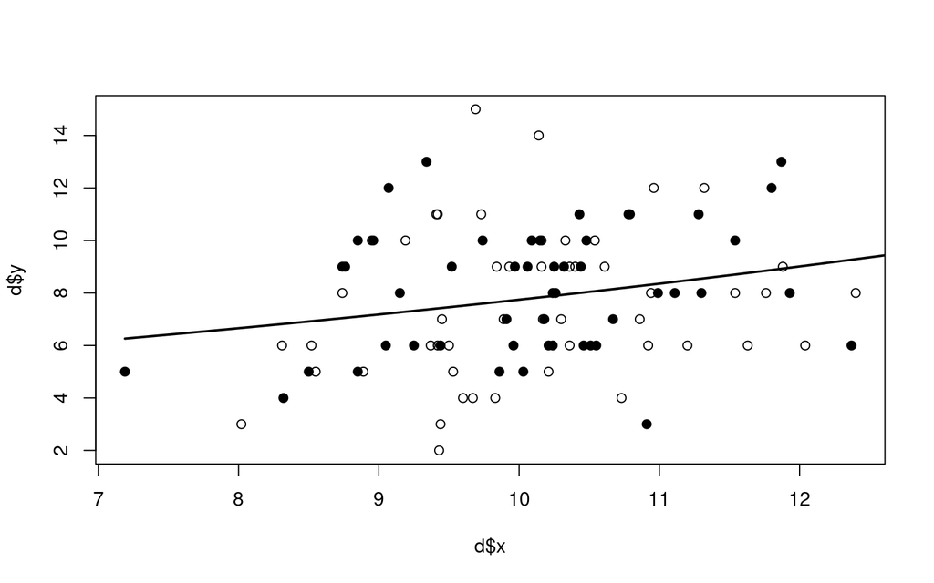

```r
d <- data
xx <- seq(min(d$x), max(d$y), length = 100)

plot(d$x, d$y, pch = c(21, 19))# [d$f])
lines(xx, exp(1.29 + 0.0757 * xx), lwd = 2)
```

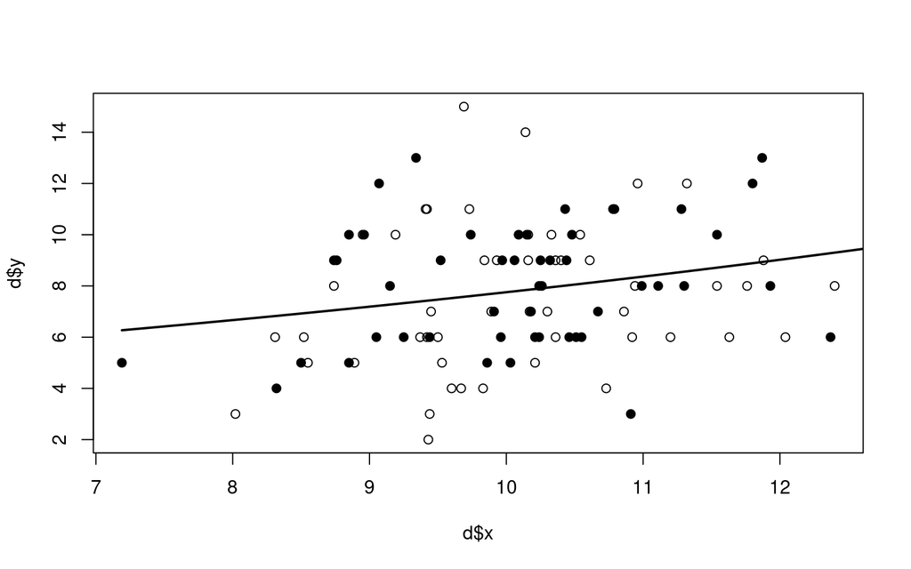

```r
# predict関数でも同じ結果となる
yy <- predict(fit, newdata = data.frame(x = xx), type = "response")
plot(d$x, d$y, pch = c(21, 19))# [d$f])
lines(xx, yy, lwd = 2)
```

## 説明変数が因子型の統計モデル

施肥効果$f_{i}$を説明変数としたモデルも検討してみる。 施肥効果だけが影響するモデルの平均値を

$$\lambda _{i}=\exp \left( \beta _{1}+\beta _{3}d_{i}\right)$$

施肥効果は$d_{i}$というダミー変数に置き換えられていて、

$$d_{i}=\begin{cases}0~~~~\left( f_{i}=C\right) \\ 1 ~~~~\left( f_{i}=T\right) \end{cases}$$

と表される。

```r
fit_f <- glm(y ~ f, data = data, family = poisson )
summary(fit_f)
```

```
##
## Call:
## glm(formula = y ~ f, family = poisson, data = data)
##
## Deviance Residuals:
##      Min        1Q    Median        3Q       Max
## -2.47515  -0.69941   0.04264   0.72467   2.25204
##
## Coefficients:
##             Estimate Std. Error z value Pr(>|z|)
## (Intercept)  2.05156    0.05070  40.463   <2e-16 ***
## fT           0.01277    0.07148   0.179    0.858
## ---
## Signif. codes:  0 '***' 0.001 '**' 0.01 '*' 0.05 '.' 0.1 ' ' 1
##
## (Dispersion parameter for poisson family taken to be 1)
##
##     Null deviance: 89.507  on 99  degrees of freedom
## Residual deviance: 89.475  on 98  degrees of freedom
## AIC: 479.25
##
## Number of Fisher Scoring iterations: 4
```

$f$の係数名がfTとなっている。これは説明変数$f_{i}$がT水準で取る値を示している。（CとTの2水準があるが、R内でfactorでCが0, Tが1と置いているため)
もし、$f_{i} = C$の時、
$$\lambda _{i}=\exp \left( 2.05+0\right) =7.77$$

$f_{i} = T$の時、

$$\lambda _{i}=\exp \left( 2.05+0.0128\right) = 7.87$$

となる。肥料をやると、ほんの少しだけ種子数は増える・・・？

```r
logLik(fit_f)
```

```
## 'log Lik.' -237.6273 (df=2)
```

対数尤度は、$x_{i}$だけのモデルよりも小さく、当てはめは悪くなっていると解釈する。

もし体サイズと施肥効果両方でモデル式を作成すると

```r
fit_all <- glm(y ~ x + f, data = data, family = poisson)
fit_all
```

```
##
## Call:  glm(formula = y ~ x + f, family = poisson, data = data)
##
## Coefficients:
## (Intercept)            x           fT
##     1.26311      0.08007     -0.03200
##
## Degrees of Freedom: 99 Total (i.e. Null);  97 Residual
## Null Deviance:       89.51
## Residual Deviance: 84.81     AIC: 476.6
```

つまり施肥効果がCならば
$$\lambda _{i}=\exp \left( 1.26+0.08x_{i}\right)$$
Tならば
$$\lambda _{i}=\exp \left( 1.26+0.08x_{i}-0.032\right)$$
と解釈する。